# PSY9550_chp3_wgma

Author

team name

Published

February 19, 2024

# Chapter 3 (all easy exercises)

```r
p_grid <- seq( from=0 , to=1 , length.out=1000 )
prior <- rep( 1 , 1000 )
likelihood <- dbinom( 6 , size=9 , prob=p_grid )
posterior <- likelihood * prior
posterior <- posterior / sum(posterior)

set.seed(100)
n_samples = 1e4
samples <- sample( p_grid , prob=posterior , size=n_samples , replace=TRUE )

samples[1:10]
```

```
 [1] 0.7137137 0.3573574 0.5985986 0.7177177 0.6296296 0.4694695 0.4734735
 [8] 0.8378378 0.9029029 0.7267267
```

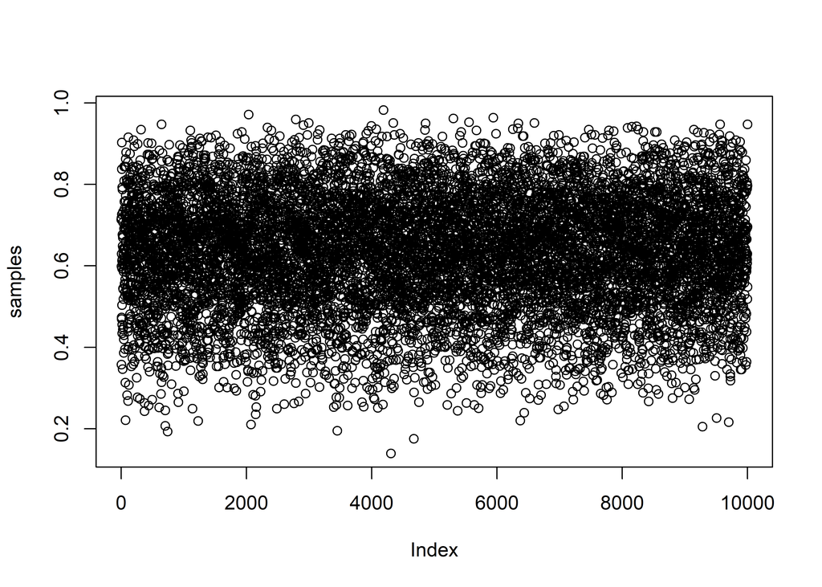

```r
plot(samples)
```

## 3E1. samples below p=0.2

```r
sum(samples < 0.2)/n_samples
```

```
[1] 4e-04
```

```r
# mean(samples < 0.2)
```

## 3E2. samples above p = 0.8?

```r
sum(samples > 0.8)/n_samples
```

```
[1] 0.1116
```

## 3E3. samples between p = 0.2 and p = 0.8

How much posterior probability lies between p = 0.2 and p = 0.8?

```r
sum(samples > 0.2 & samples < 0.8)/n_samples
```

```
[1] 0.888
```

```r
#note to self: mean(between(samples, 0.2, 0.8))
```

## 3E4. prob mass 20% below which p

20% of the posterior probability lies below which value of p?

```r
quantile (samples, 0.2)
```

```
      20%
0.5185185
```

## 3E5. prob mass 20% above which p

20% of the posterior probability lies above which value of p?

```r
quantile(samples, 0.8)
```

```
      80%
0.7557558
```

## 3E6. Narrowest interval with prob mass = 66%

Which values of p contain the narrowest interval equal to 66% of the posterior probability?

```r
HPDI( samples , prob=0.66 )
```

```
    |0.66     0.66|
0.5085085 0.7737738
```

## 3E7. assume equal prob mass each side of interval of prob mass 66%

Which values of p contain 66% of the posterior probability, assuming equal posterior probability both below and above the interval? Equal posterior probability on both sides of the interval means the middle p of the interval is the median. there are 34%/2 = 17% on each side. Check for p at prob mass 17% and 83% (100-17).

```r
# lower p
quantile(samples, 0.17)
```

```
      17%
0.5025025
```

```r
# high p
quantile(samples, 0.83)
```

```
      83%
0.7697698
```

```r
# or: PI(samples, prob = 0.66)
```

# Chapter 3 (M1-M5)

## 3M1. W=8, N =15

Suppose the globe tossing data had turned out to be 8 water in 15 tosses. Construct the posterior distribution, using grid approximation. Use the same flat prior as before.

```r
grid_size = 1000

p_grid <- seq( from=0 , to=1 , length.out=grid_size )
prior <- rep( 1 , grid_size )
likelihood <- dbinom( 8 , size=15 , prob=p_grid )

posterior_uni <- likelihood * prior
posterior_uni <- posterior_uni / sum(posterior_uni)
```

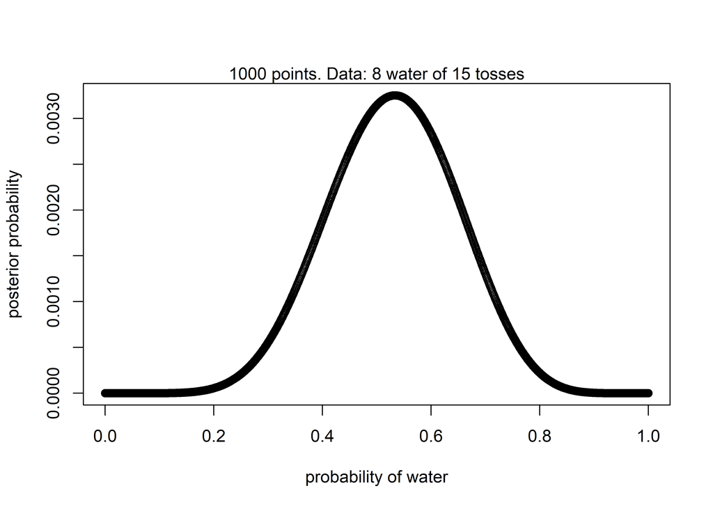

```r
plot( p_grid , posterior_uni ,
      type="b" ,
      xlab="probability of water" ,
      ylab="posterior probability" )
mtext( "1000 points. Data: 8 water of 15 tosses" )
```

Draw 10,000 samples from the grid approximation from above. Then use the samples to calculate the 90% HPDI for p.

```r
#posterior_uni

set.seed(57)
n_samples = 1e4
samples_uni <- sample( p_grid , prob=posterior_uni , size=n_samples , replace=TRUE )
HPDI( samples_uni , prob=0.9 )
```

```
     |0.9      0.9|
0.3373373 0.7207207
```

## 3M3. 8/15 posterior -> samples , p for 8/15

Construct a posterior predictive check for this model and data. This means simulate the distribution of samples, averaging over the posterior uncertainty in p. What is the probability of observing 8 water in 15 tosses?

```r
#posterior_uni
#sample_uni
set.seed(57)
n=15

n_simulations = 1e4
simulated_data_uni <-  rbinom( n_simulations , size=n , prob=samples )
simulated_data_uni[1:10]
```

```
 [1] 12  5 12 12  8  8 11 13 14 12
```

```r
table(simulated_data_uni)/n_simulations
```

```
simulated_data_uni
     0      1      2      3      4      5      6      7      8      9     10
0.0003 0.0008 0.0040 0.0137 0.0235 0.0432 0.0621 0.0880 0.1030 0.1408 0.1373
    11     12     13     14     15
0.1277 0.1094 0.0836 0.0452 0.0174
```

## 3M4. posterior 8/15, p for 6/9

Using the posterior distribution constructed from the new (8/15) data, now calculate the probability of observing 6 water in 9 tosses.

```r
n_simulations = 1e4
simulated_data_uni <-  rbinom( n_simulations , size=9 , prob=samples )
simulated_data_uni[1:10]
```

```
 [1] 8 3 4 5 5 2 4 8 9 4
```

The probability of observing 6 water out of 9 tosses from the simulated data is 20.0%.

```r
table(simulated_data_uni)/n_simulations
```

```
simulated_data_uni
     0      1      2      3      4      5      6      7      8      9
0.0018 0.0135 0.0365 0.0749 0.1333 0.1804 0.2000 0.1828 0.1237 0.0531
```

## 3M5.

Start over at 3M1, but now use a prior that is zero below p = 0.5 and a constant above p = 0.5. This corresponds to prior information that a majority of the Earth’s surface is water. Repeat each problem above and compare the inferences. What difference does the better prior make? If it helps, compare inferences (using both priors) to the true value p = 0.7.

```r
grid_size = 1000
w = 8
n = 15

p_grid <- seq( from=0 , to=1 , length.out=grid_size )
prior <- prior <- 1*(p_grid>= 0.5)
likelihood <- dbinom( w , size=n , prob=p_grid )

# dich = dichotomous
posterior_dich <- likelihood * prior
posterior_dich <- posterior_dich / sum(posterior_dich)
```

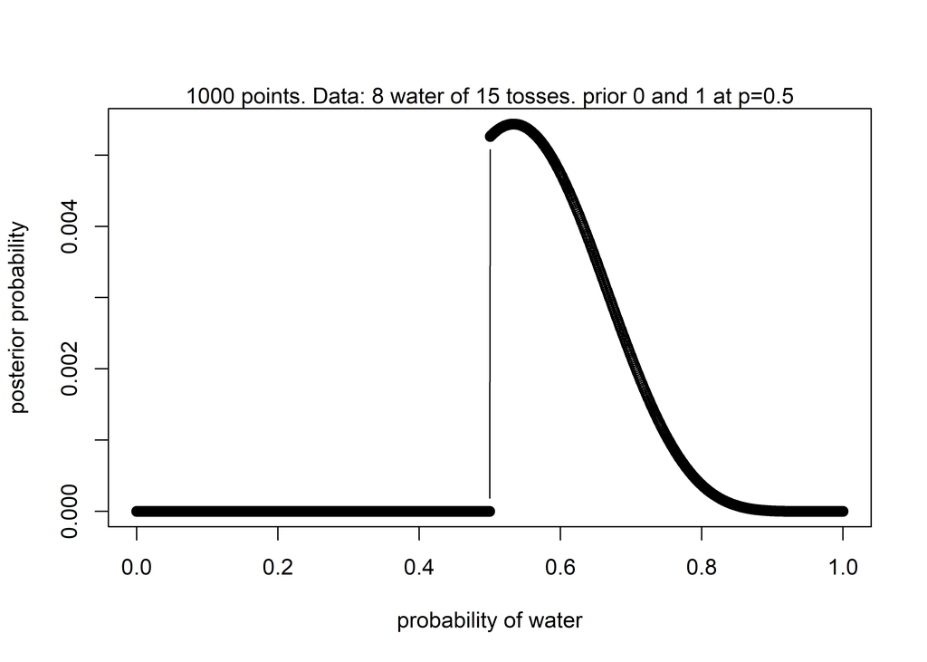

```r
plot( p_grid , posterior_dich ,
      type="b" ,
      xlab="probability of water" ,
      ylab="posterior probability" )
mtext( "1000 points. Data: 8 water of 15 tosses. prior 0 and 1 at p=0.5" )
```

The 90% HPDI for p.(3M2)

```r
set.seed(57)
n_samples = 1e4
samples_dich <- sample( p_grid , prob=posterior_dich , size=n_samples , replace=TRUE )
HPDI( samples_dich , prob=0.9 )
```

```
     |0.9      0.9|
0.5005005 0.7107107
```

```r
n_simulations = 1e4
simulated_data_dich <-  rbinom( n_simulations , size=15 , prob=samples_dich )
# simulated_data[1:10]
table(simulated_data_dich)/n_simulations
```

```
simulated_data_dich
     1      2      3      4      5      6      7      8      9     10     11
0.0002 0.0006 0.0037 0.0122 0.0329 0.0682 0.1116 0.1580 0.1732 0.1694 0.1305
    12     13     14     15
0.0845 0.0387 0.0133 0.0030
```

```r
# or: mean(simulated_data_dich == 8)
```

(3M4) The probability of observing 6 water out of 9 tosses from the simulated data is 19.9%. For an uniform prior the probability was 20.0%.

```r
n_simulations = 1e4
simulated_data_dich <-  rbinom( n_simulations , size=9 , prob=samples )
# simulated_data[1:10]
table(simulated_data_dich)/n_simulations
```

```
simulated_data_dich
     0      1      2      3      4      5      6      7      8      9
0.0019 0.0136 0.0352 0.0726 0.1261 0.1787 0.1987 0.1936 0.1279 0.0517
```

Comparing distribution of simulated samples for two priors: uniform and dichotomous at p=0.5. We also compare it to the simulated distribution assuming p=0.7 as true value.

```r
simulated_data_real <-  rbinom( n_simulations , size=9 , prob=0.7 )
```

When plotting the distributions of the simulated data, the two distributions based on data 8 water out of 15 tosses seem to have almost identical overlapping distributions (even when they have different priors).

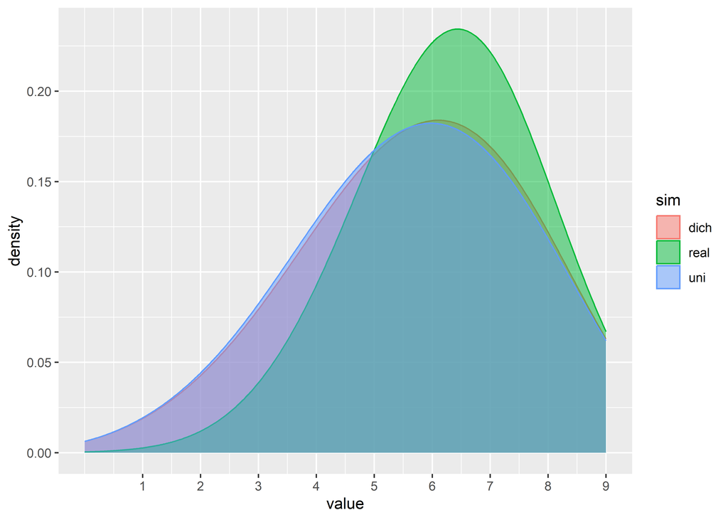

```r
# library(tidyverse)
data.frame(prior=prior,
           uni = simulated_data_uni,
           dich=simulated_data_dich,
           real=simulated_data_real) %>%
tibble() %>%
pivot_longer(!prior, names_to = "sim", values_to = "value") %>%

ggplot(aes(x=value, fill=sim, color =sim))+
  geom_density(bw = 1, alpha = 0.5)+
# geom_histogram(alpha=0.7, position = "identity")+
  scale_x_continuous(breaks = seq(1,12,1) )
```

# Clarification and or discussion questions

```r
HPDI(samples_uni, prob = 0.9)
```

```
     |0.9      0.9|
0.3373373 0.7207207
```

```r
HPDI(samples_dich, prob = 0.9)
```

```
     |0.9      0.9|
0.5005005 0.7107107
```